# Okanagan Chinook Population Viability Analysis

## Context

Okanagan Chinook were assessed in May 2005 by the Committee on the Status of Endangered Wildlife in Canada (COSEWIC) as Endangered in an Emergency Assessment.This status was re-examined in April 2006 to be Threatened due to the potential for rescue from nearby Upper Columbia River Chinook populations. In 2010, the Federal Minister of Environment recommended that the Okanagan Chinook population not be listed under the Federal Species at Risk Act. Reasons for not listing this population included substantial losses in revenue to the BC economy and even in the complete absence of fisheries exploitation the recovery potential was low. COSEWIC reassessed the status as Endangered in 2017, stating that rescue via straying from nearby populations is considered unlikely. In B.C., Okanagan Chinook Salmon are listed as “apparently secure” – not at risk of extinction – however the population has a relatively high conservation priority under the BC Ministry of Environment Conservation Framework Priority.

Since 2002, the [Okanagan Nation Alliance (ONA)](https://www.syilx.org) has been actively involved in the study and conservation of Okanagan Chinook, including enumeration, biological sampling studies, and habitat enhancement. ONA collaborated with Fisheries and Oceans, Columbia River Intertribal Fish Commission, and Summit Environmental to produce an Okanagan Chinook Recovery Potential Assessment (RPA) in 2006. Furthermore, ONA produced a subsequent RPA in 2016.

As part of the RPA process a population viability analysis (PVA) was conducted. This script contains the revised PVA code used for the most recent RPA, which is scheduled to be published in 2020.

## Premable

Before this analysis can be run you will need the following packages installed in your R distribution.

```r
package.list <- c('devtools', 'tidyverse', 'ggplot2', 'scales', 'gridExtra', 'openxlsx')
```

Next we will installs any packages that may be missing.

```
All required packages have already been installed.
```

With the packages installed we can load the custom CNPVA r-package that is used to do the calculations along with any other required packages.

```r
rm(list=ls())      # clear workspace
library(devtools)  # development tools
library(openxlsx)  # Useful for creating excel files
load_all("CNPVA")  # Sideload CNPVA custom R package using devtools
```

Finally, we will create an excel workbook to save our analysis output into.

```r
wb <- createWorkbook()
wb.out <- createWorkbook()
```

## Settings

First we create a list object to save the simulation scenario results.

```r
set.seed(3980) # Ensure the results are exactly repeatable.

# Number of simulation iterations
# nsim <- 1000     # Quick run
nsim <- 10000    # Final run

all.runs <- list()
results <- list(
  plots = list(spawners = list(), adults = list()),
  data = list(spawners=list(), adults=list())
)
```

### Default Settings

Currently the `S.osar` represent survival from MCN dam to age 2.

```r
setdef <- GetSettings("default v2")
str(setdef)
```

```
List of 15
 $ rec.alpha      : num 136
 $ rec.beta       : num 2400
 $ rec.sigma      : num 0.53
 $ seed.spawners  : num 50
 $ supplementation: num 0
 $ suppl.fitness  : num 1
 $ S.juv          : num 0.35
 $ S.juv.sig      : num 0.09
 $ S.osar         : num 0.084
 $ surv.ocean     : Named num [1:4] 1 0.7 0.8 0.9
  ..- attr(*, "names")= chr [1:4] "age.1.2" "age.2.3" "age.3.4" "age.4.5"
 $ hr.ocean       : num 0.25
 $ spawn.prob     : Named num [1:4] 0.043 0.26 0.72 1
  ..- attr(*, "names")= chr [1:4] "age.2" "age.3" "age.4" "age.5"
 $ S.riv          : num 0.94
 $ S.riv.sig      : num 0.05
 $ hr.river       : num 0.42
```

Compute expected returns for the 15,000 releases

```r
n.rel <- 15000

S.eo <- setdef$S.osar
HR.o <- setdef$hr.ocean
S.o  <- setdef$surv.ocean
Spwn <- setdef$spawn.prob
S.r  <- setdef$S.riv
HR.r <- setdef$hr.river

spawners <- rep(NA,4)
names(spawners) <- paste0("age.", 2:5)
# Age 2 Spawners
spawners['age.2'] <- n.rel * S.eo * (1 - HR.o) *  Spwn[1] * S.r * (1 - HR.r)
# Age 3 Spawners
spawners['age.3'] <- n.rel * S.eo * (1 - HR.o) * (1 - Spwn[1]) * S.o[2] * (1 - HR.o) *  Spwn[2] * S.r * (1 - HR.r)
# Age 4 Spawners
spawners['age.4'] <- n.rel * S.eo * (1 - HR.o) * (1 - Spwn[1]) * S.o[2] * (1 - HR.o) * (1 - Spwn[2]) * S.o[3] * (1 - HR.o) * Spwn[3] * S.r * (1 - HR.r)
# Age 5 Spawners
spawners['age.5'] <- n.rel * S.eo * (1 - HR.o) * (1 - Spwn[1]) * S.o[2] * (1 - HR.o) * (1 - Spwn[2]) * S.o[3] * (1 - HR.o) * (1 - Spwn[3]) * S.o[4] * (1 - HR.o) * 1 * S.r * (1 - HR.r)

spawners
```

```
   age.2    age.3    age.4    age.5
22.15420 67.30266 82.75121 21.72219
```

Total number expected to have returned

```r
round(sum(spawners))
```

```
[1] 194
```

### Upriver survival

Load the upstream survival data included in the CNPVA package

```r
data(upstream)
upstream
```

|  | Year | Survival |
| --- | --- | --- |
| 1 | 1973 | 0.498 |
| 2 | 1974 | 0.405 |
| 3 | 1975 | 0.479 |
| 4 | 1976 | 0.241 |
| 5 | 1977 | 0.560 |
| 6 | 1978 | 0.646 |
| 7 | 1979 | 0.709 |
| 8 | 1980 | 0.552 |
| 9 | 1981 | 0.423 |
| 10 | 1982 | 0.516 |

[output cut: 34 more lines]

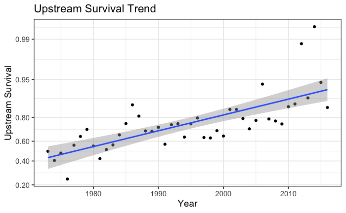

Next we will create a linear model fit object containing the above regression relationship:

```r
summary(fit <- lm(qlogis(Survival)~Year, upstream))
```

```
Call:
lm(formula = qlogis(Survival) ~ Year, data = upstream)

Residuals:
     Min       1Q   Median       3Q      Max
-1.07284 -0.56633 -0.00847  0.22936  2.71519

Coefficients:
              Estimate Std. Error t value Pr(>|t|)
(Intercept) -1.285e+02  1.830e+01  -7.020 1.36e-08 ***
Year         6.498e-02  9.175e-03   7.082 1.11e-08 ***
---
Signif. codes:  0 ‘***’ 0.001 ‘**’ 0.01 ‘*’ 0.05 ‘.’ 0.1 ‘ ’ 1

Residual standard error: 0.7729 on 42 degrees of freedom
Multiple R-squared:  0.5442,    Adjusted R-squared:  0.5334
F-statistic: 50.15 on 1 and 42 DF,  p-value: 1.111e-08
```

This empirical regression relationship is used in the PVA to predict future survival rates with uncertainty (i.e., prediction intervals). To do so we must include the fit object in the settings passed to the simulator

```r
setdef$S.riv <- fit
```

## Scenario Runs

The PVA considered a number of future scenarios over which to assess population viability these included:

1. Mortality reductions through habitat improvements
2. Hatchery supplementation
3. Additional scenarios which combined aspects of (1) and (2)

In this section we run the individual scenarios and add each run as a list element in the `all.runs` object.

However, first we must run the baseline or “status quo” scenario which captures our expectations of the future if no changes are implemented.

```r
all.runs[['Baseline']] <- PopSim(setdef, n.sim=nsim)
```

### Mortality Reductions (Habitat Improvements)

It is too early in the recovery process to discuss what survival improvements associated with a particular habitat improvement strategy. As such, we considered reductions in juvenile mortality, which we apply to the `S.juv` parameter.

#### Scenarios

A 10% reduction in juvenile mortality.

```r
settings <- setdef
settings$S.juv <-  1 - ((1- settings$S.juv) * (1 - 0.10))
all.runs[['10% mort reduction']] <- PopSim(settings, n.sim = nsim)
```

A 30% reduction in juvenile mortality.

```r
settings <- setdef
settings$S.juv <-  1 - ((1- settings$S.juv) * (1 - 0.30))
all.runs[['30% mort reduction']] <- PopSim(settings, n.sim = nsim)
```

A 50% reduction in juvenile mortality.

```r
settings <- setdef
settings$S.juv <-  1 - ((1- settings$S.juv) * (1 - 0.5))
all.runs[['50% mort reduction']] <- PopSim(settings, n.sim = nsim)
```

#### Outcome Table

Determine the outcome probabilities and assign the IPCC outcome categories.

```r
(out1.tab <- OutcomeTable(run.set))
```

```
NOTE: time periods used in OutcomeTable are hard coded.
```

| Scenario | Prob.short | Prob.long | Trend.short | Trend.long | Outcome.short | Outcome.long | TrendCat.short | TrendCat.long |
| --- | --- | --- | --- | --- | --- | --- | --- | --- |
| Baseline | 0 | 0.0000 | -67.149928 | -66.014111 | Very Unlikely | Very Unlikely | Negative | Negative |
| 10% mort reduction | 0 | 0.0000 | -48.485946 | -45.878794 | Very Unlikely | Very Unlikely | Negative | Negative |
| 30% mort reduction | 0 | 0.0000 | 8.782328 | 9.958855 | Very Unlikely | Very Unlikely | Positive | Positive |
| 50% mort reduction | 0 | 0.0301 | 89.233552 | 76.223737 | Very Unlikely | Very Unlikely | Positive | Positive |

```r
BlankWorkSheet(wb.out, sheet = "Habitat")
writeData(wb.out, "Habitat", out1.tab)
```

#### Overview

Diagnostics used as part of the original project assessments. Only the average spawner panel was used in the final RPA.

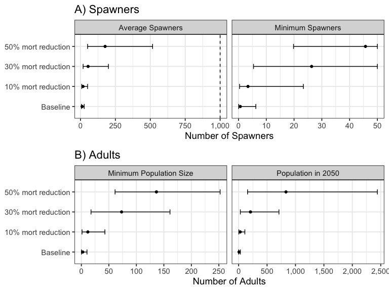

#### Detailed Spawners

Diagnostic used to look at the distribution of spawners being produced across simulation iterations.

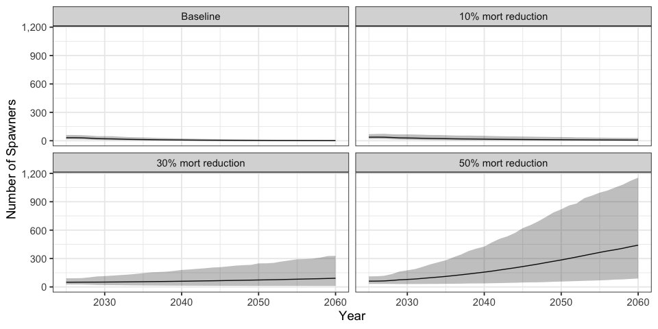

```r
PlotSpawners(run.set)
```

Summary statistics for the minimum number of spawners:

```r
spawn.tab$Minimum
```

| Type | Scenario | Mean | SD | Median | Lower1 | Upper99 | Lower95 | Upper95 |
| --- | --- | --- | --- | --- | --- | --- | --- | --- |
| Minimum Spawners | Baseline | 1.049704 | 1.269516 | 0.6379224 | 0.05942876 | 6.224527 | 0.08677429 | 4.341385 |
| Minimum Spawners | 10% mort reduction | 4.898538 | 4.781465 | 3.4029350 | 0.37079021 | 23.348956 | 0.51407166 | 17.545786 |
| Minimum Spawners | 30% mort reduction | 27.231578 | 11.935516 | 26.3237402 | 5.39190033 | 50.000000 | 7.19891176 | 50.000000 |
| Minimum Spawners | 50% mort reduction | 42.699450 | 8.348455 | 45.7227743 | 19.81361363 | 50.000000 | 23.14083887 | 50.000000 |

Summary statistics for the average number of spawners:

```r
spawn.tab$Average
```

| Type | Scenario | Mean | SD | Median | Lower1 | Upper99 | Lower95 | Upper95 |
| --- | --- | --- | --- | --- | --- | --- | --- | --- |
| Average Spawners | Baseline | 12.94151 | 4.218434 | 12.01445 | 7.079457 | 26.75491 | 7.599259 | 23.45141 |
| Average Spawners | 10% mort reduction | 20.11207 | 8.694495 | 18.06406 | 9.077146 | 50.88200 | 10.002275 | 42.23106 |
| Average Spawners | 30% mort reduction | 64.30095 | 37.790241 | 54.47982 | 18.895172 | 200.15174 | 21.537738 | 164.08664 |
| Average Spawners | 50% mort reduction | 196.88839 | 100.914856 | 176.34765 | 50.842123 | 516.36145 | 60.574481 | 442.14824 |

#### Detailed Adults

Distribution of the minimum adults population size across all years in the simulation and the distribution of the adult population size in 2050 (metric used in the previous Okanagan Chinook RPA).

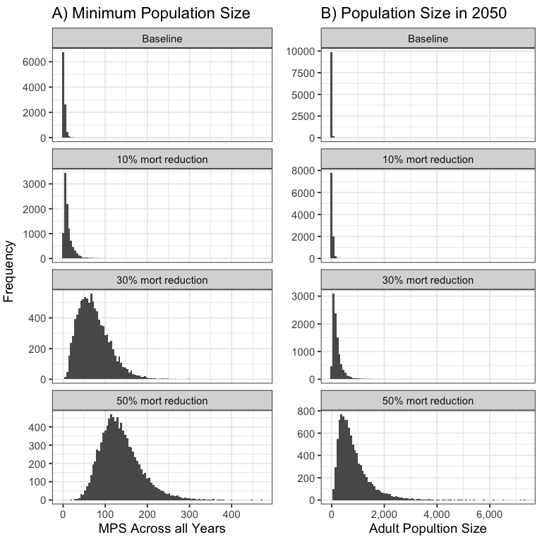

```r
PlotAdultMetrics(run.set, bins=100)
```

#### Alternative Metrics

Empirical cumulative distribution plots of the minimum population size and population size in 2050 performance metrics used in the previous Okanagan Chinook RPA.

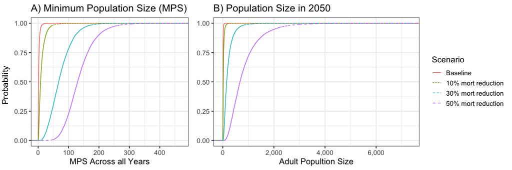

```r
p.ecdf <- PlotMetricECDF(run.set, type="both", panel.widths = c(1,1.75))
```

```r
# ggsave(filename = "habitat-ecdf.png", width=10, height=4, plot=p.ecdf)
```

Statistics for minimum population size metric:

```r
adults.tab$MPS
```

| Scenario | Mean | SD | Lower1 | Upper99 | Lower95 | Upper95 |
| --- | --- | --- | --- | --- | --- | --- |
| Baseline | 2.43746 | 2.996502 | 0.1384455 | 15.02717 | 0.2013855 | 10.21249 |
| 10% mort reduction | 11.73545 | 11.883206 | 0.8766548 | 55.55645 | 1.2171741 | 42.79335 |
| 30% mort reduction | 73.10693 | 37.673021 | 13.3592962 | 184.38700 | 17.5339946 | 161.15055 |
| 50% mort reduction | 136.50658 | 48.608585 | 51.9198003 | 284.83622 | 61.2866329 | 252.30813 |

Statistics for population size in 2050 metric:

```r
adults.tab$POP2050
```

| Scenario | Mean | SD | Lower1 | Upper99 | Lower95 | Upper95 |
| --- | --- | --- | --- | --- | --- | --- |
| Baseline | 7.701842 | 8.590673 | 0.5895687 | 40.80014 | 0.8104177 | 30.14742 |
| 10% mort reduction | 27.935775 | 30.420818 | 2.4336639 | 148.47005 | 3.2492449 | 109.24186 |
| 30% mort reduction | 207.913042 | 194.653797 | 21.6925649 | 950.21037 | 29.9582721 | 708.69576 |
| 50% mort reduction | 832.527007 | 611.819457 | 110.3245597 | 2999.95973 | 156.7591634 | 2440.38358 |

### Hatchery Supplementation

Hatchery supplementation looks at the effect of supplementing the wild population with hatchery releases each year. Smolts are assumed to be full fitness, for reduced fitness can be consider for a given result by increasing the actual number of smolts release by what is believed to be the fitness deficit.

#### Scenarios

Hatchery Augmentation 50K (full fitness)

```r
settings <- GetSettings('default v2')
settings$supplementation = 5 * 10^4
all.runs[['Hatchery 50K']] <- PopSim(settings, n.sim = nsim)
```

Hatchery Augmentation 100K (full fitness)

```r
settings <- GetSettings('default v2')
settings$supplementation = 1 * 10^5
all.runs[['Hatchery 100K']] <- PopSim(settings, n.sim = nsim)
```

Hatchery Augmentation 150K (full fitness)

```r
settings <- GetSettings('default v2')
settings$supplementation = 1.5 * 10^5
all.runs[['Hatchery 150K']] <- PopSim(settings, n.sim = nsim)
```

Hatchery Augmentation 250K (full fitness)

```r
settings <- GetSettings('default v2')
settings$supplementation = 2.5 * 10^5
all.runs[['Hatchery 250K']] <- PopSim(settings, n.sim = nsim)
```

Hatchery Augmentation 500K (full fitness)

```r
settings <- GetSettings('default v2')
settings$supplementation = 5 * 10^5
all.runs[['Hatchery 500K']] <- PopSim(settings, n.sim = nsim)
```

#### Outcome Table

```r
(out2.tab <- OutcomeTable(run.set))
```

```
NOTE: time periods used in OutcomeTable are hard coded.
```

| Scenario | Prob.short | Prob.long | Trend.short | Trend.long | Outcome.short | Outcome.long | TrendCat.short | TrendCat.long |
| --- | --- | --- | --- | --- | --- | --- | --- | --- |
| Baseline | 0.0000 | 0.0000 | -67.14993 | -66.014111 | Very Unlikely | Very Unlikely | Negative | Negative |
| Hatchery 50K | 0.0014 | 0.0124 | 54.64450 | 12.800885 | Very Unlikely | Very Unlikely | Positive | Positive |
| Hatchery 100K | 0.2950 | 0.7135 | 44.50454 | 8.766876 | Unlikely | Likely | Positive | Positive |
| Hatchery 150K | 0.9599 | 1.0000 | 34.70765 | 6.521446 | Very Likely | Very Likely | Positive | Positive |
| Hatchery 250K | 1.0000 | 1.0000 | 23.33336 | 4.016531 | Very Likely | Very Likely | Positive | Positive |
| Hatchery 500K | 1.0000 | 1.0000 | 11.22727 | 1.761404 | Very Likely | Very Likely | Positive | Positive |

```r
BlankWorkSheet(wb.out, sheet = "Hatchery")
writeData(wb.out, "Hatchery", out2.tab)
```

#### Overview

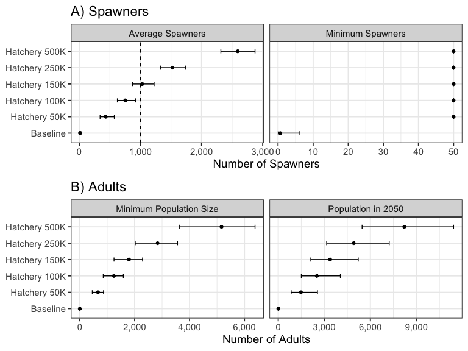

#### Detailed Spawners

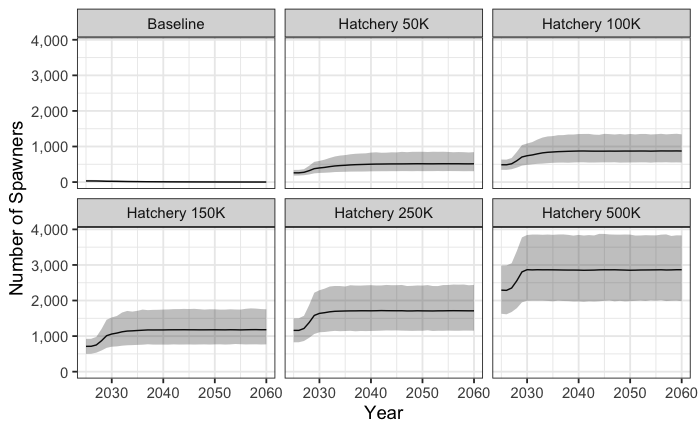

```r
PlotSpawners(run.set)
```

```r
# ggsave(filename = "hatchery-scenarios--spawners.png", width=10, height=8, plot=p)
```

```r
spawn.tab$Minimum
```

| Type | Scenario | Mean | SD | Median | Lower1 | Upper99 | Lower95 | Upper95 |
| --- | --- | --- | --- | --- | --- | --- | --- | --- |
| Minimum Spawners | Baseline | 1.049704 | 1.269516 | 0.6379224 | 0.05942876 | 6.224527 | 0.08677429 | 4.341385 |
| Minimum Spawners | Hatchery 50K | 50.000000 | 0.000000 | 50.0000000 | 50.00000000 | 50.000000 | 50.00000000 | 50.000000 |
| Minimum Spawners | Hatchery 100K | 50.000000 | 0.000000 | 50.0000000 | 50.00000000 | 50.000000 | 50.00000000 | 50.000000 |
| Minimum Spawners | Hatchery 150K | 50.000000 | 0.000000 | 50.0000000 | 50.00000000 | 50.000000 | 50.00000000 | 50.000000 |
| Minimum Spawners | Hatchery 250K | 50.000000 | 0.000000 | 50.0000000 | 50.00000000 | 50.000000 | 50.00000000 | 50.000000 |
| Minimum Spawners | Hatchery 500K | 50.000000 | 0.000000 | 50.0000000 | 50.00000000 | 50.000000 | 50.00000000 | 50.000000 |

```r
spawn.tab$Average
```

| Type | Scenario | Mean | SD | Median | Lower1 | Upper99 | Lower95 | Upper95 |
| --- | --- | --- | --- | --- | --- | --- | --- | --- |
| Average Spawners | Baseline | 12.94151 | 4.218434 | 12.01445 | 7.079457 | 26.75491 | 7.599259 | 23.45141 |
| Average Spawners | Hatchery 50K | 435.80595 | 49.250464 | 431.34488 | 340.115405 | 572.67047 | 352.219104 | 545.24284 |
| Average Spawners | Hatchery 100K | 756.58897 | 64.807839 | 752.42089 | 623.225689 | 920.63264 | 641.606951 | 893.26474 |
| Average Spawners | Hatchery 150K | 1034.05609 | 75.423955 | 1031.18975 | 868.924900 | 1223.85433 | 891.749178 | 1189.74733 |
| Average Spawners | Hatchery 250K | 1525.90066 | 88.608785 | 1522.98704 | 1331.877708 | 1740.69561 | 1359.062775 | 1704.90651 |
| Average Spawners | Hatchery 500K | 2592.32647 | 119.325480 | 2592.18218 | 2315.546080 | 2874.60080 | 2355.875185 | 2826.65828 |

#### Detailed Adults

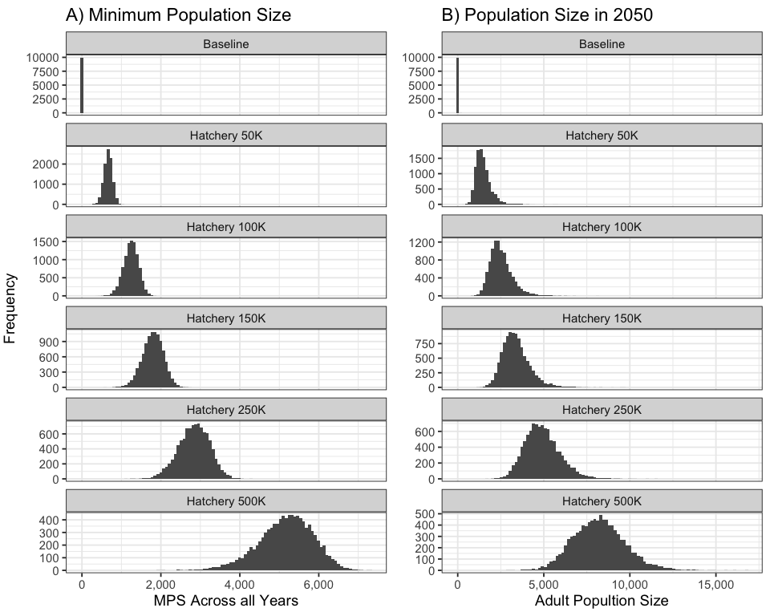

#### Alternative metrics

```r
adults.tab$MPS
```

| Scenario | Mean | SD | Lower1 | Upper99 | Lower95 | Upper95 |
| --- | --- | --- | --- | --- | --- | --- |
| Baseline | 2.43746 | 2.996502 | 0.1384455 | 15.02717 | 0.2013855 | 10.21249 |
| Hatchery 50K | 665.88320 | 105.187602 | 415.9178708 | 901.50725 | 457.8613834 | 866.40137 |
| Hatchery 100K | 1241.48885 | 188.661175 | 784.9560603 | 1646.30500 | 856.7951616 | 1589.41642 |
| Hatchery 150K | 1795.32825 | 266.417625 | 1124.4317896 | 2379.36715 | 1248.3585812 | 2288.41552 |
| Hatchery 250K | 2836.05575 | 395.990729 | 1856.0016605 | 3688.82098 | 2021.9180546 | 3561.42649 |
| Hatchery 500K | 5163.20879 | 693.434796 | 3337.0788345 | 6573.45707 | 3638.9472331 | 6384.47535 |

```r
adults.tab$POP2050
```

| Scenario | Mean | SD | Lower1 | Upper99 | Lower95 | Upper95 |
| --- | --- | --- | --- | --- | --- | --- |
| Baseline | 7.701842 | 8.590673 | 0.5895687 | 40.80014 | 0.8104177 | 30.14742 |
| Hatchery 50K | 1479.557013 | 445.935026 | 765.8371183 | 2935.30085 | 843.6539241 | 2552.65875 |
| Hatchery 100K | 2513.009831 | 654.505695 | 1356.8054234 | 4566.73127 | 1504.7936452 | 4048.14584 |
| Hatchery 150K | 3380.941332 | 791.862668 | 1909.9581591 | 5777.50131 | 2119.6104384 | 5210.66134 |
| Hatchery 250K | 4915.598915 | 1037.229812 | 2897.2823251 | 7842.14257 | 3155.1525072 | 7226.93283 |
| Hatchery 500K | 8212.276287 | 1512.079168 | 4945.4485230 | 12115.94140 | 5462.2311385 | 11419.21096 |

Empirial cumulative distribution plots of performance metrics.

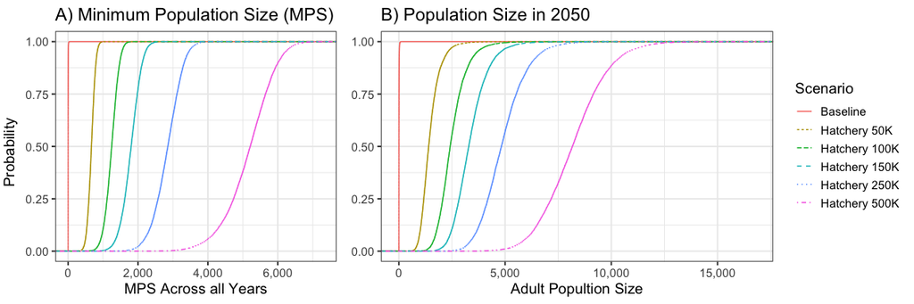

```r
p.ecdf <- PlotMetricECDF(run.set, type="both", panel.widths = c(1,1.75))
```

```r
# ggsave(filename = "hatchery-ecdf.png", width=10, height=4, plot=p.ecdf)
```

### Additional Scenarios

#### Scenarios

No harvest (freshwater or marine)

```r
settings <- GetSettings('default v2')
settings$hr.river <- 0
settings$hr.ocean <- 0
all.runs[['No Harvest']] <- PopSim(settings, n.sim = nsim)
```

A natural doubling of productivity.

```r
settings <- GetSettings('default v2')
settings$rec.alpha <- settings$rec.alpha *2
all.runs[['Productivity 2x']] <- PopSim(settings, n.sim = nsim)
```

150K hatchery program and a 30% reduction in juvenile mortality.

```r
settings <- GetSettings('default v2')
settings$supplementation = 1.5 * 10^5    # 150K
settings$S.juv <-  1 - ((1- settings$S.juv)* (1 - 0.30))
all.runs[['Hatchery 150K + 30% Mort Reduction']] <- PopSim(settings, n.sim = nsim)
```

150K hatchery program and no harvest (freshwater or marine).

```r
settings <- GetSettings('default v2')
settings$supplementation = 1.5 * 10^5    # 150K
settings$hr.river <- 0
settings$hr.ocean <- 0
# settings$S.juv <-  1 - ((1- settings$S.juv)* (1 - 0.30) * (1 - 0.25)* (1 - 0.1))
# settings$S.osar = settings$S.osar * 2
all.runs[['Hatchery 150K + No Harvest']] <- PopSim(settings, n.sim = nsim)
```

No harvest (freshwater or marine) and a 30% reduction in juvenile mortality.

```r
settings <- GetSettings('default v2')
settings$hr.river <- 0
settings$hr.ocean <- 0
settings$S.juv <-  1 - ((1- settings$S.juv)* (1 - 0.30))
# settings$S.osar = settings$S.osar * 2
all.runs[['No Harvest + 30% Mort Reduction']] <- PopSim(settings, n.sim = nsim)
```

#### Results

```r
runs <- c(
  "No Harvest",
  "Productivity 2x",
  # "Hatchery 250K",   # duplication removed
  "Hatchery 150K + 30% Mort Reduction",
  "Hatchery 150K + No Harvest",
  "No Harvest + 30% Mort Reduction"
  )
run.set <- all.runs[runs]

# Compute summary tables
results[['data']][['spawners']][['Other']] <- spawn.tab <- SummarizeSpawners(run.set, start.yr=2022)
results[['data']][['adults']][['Other']] <- adults.tab <- SummarizeMetrics(run.set)    # Adult performance metrics
```

#### Outcome Table

```
NOTE: time periods used in OutcomeTable are hard coded.
```

| Scenario | Prob.short | Prob.long | Trend.short | Trend.long | Outcome.short | Outcome.long | TrendCat.short | TrendCat.long |
| --- | --- | --- | --- | --- | --- | --- | --- | --- |
| No Harvest | 0.6374 | 0.9999 | 645.68902 | 125.872458 | About as likely as not | Very Likely | Positive | Positive |
| Productivity 2x | 0.0005 | 0.0672 | 130.70285 | 81.196329 | Very Unlikely | Very Unlikely | Positive | Positive |
| Hatchery 150K + 30% Mort Reduction | 1.0000 | 1.0000 | 36.33416 | 6.246328 | Very Likely | Very Likely | Positive | Positive |
| Hatchery 150K + No Harvest | 1.0000 | 1.0000 | 19.31347 | 2.621357 | Very Likely | Very Likely | Positive | Positive |
| No Harvest + 30% Mort Reduction | 0.9998 | 1.0000 | 868.82277 | 74.835161 | Very Likely | Very Likely | Positive | Positive |

#### Overview

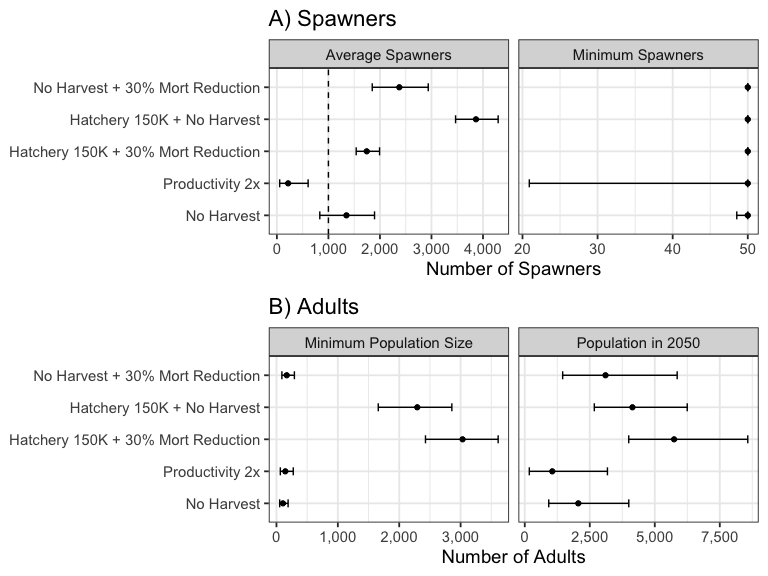

#### Detailed Spawners

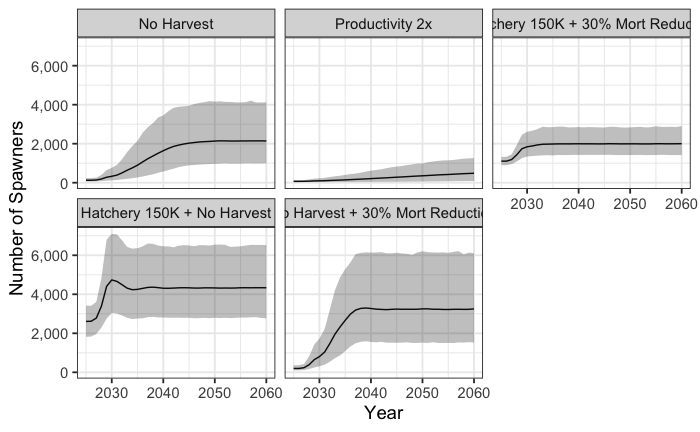

```r
PlotSpawners(run.set)
```

```r
spawn.tab$Minimum
```

| Type | Scenario | Mean | SD | Median | Lower1 | Upper99 | Lower95 | Upper95 |
| --- | --- | --- | --- | --- | --- | --- | --- | --- |
| Minimum Spawners | No Harvest | 49.93118 | 0.8016567 | 50 | 48.53555 | 50 | 50.00000 | 50 |
| Minimum Spawners | Productivity 2x | 44.63811 | 7.7414836 | 50 | 20.90673 | 50 | 24.44377 | 50 |
| Minimum Spawners | Hatchery 150K + 30% Mort Reduction | 50.00000 | 0.0000000 | 50 | 50.00000 | 50 | 50.00000 | 50 |
| Minimum Spawners | Hatchery 150K + No Harvest | 50.00000 | 0.0000000 | 50 | 50.00000 | 50 | 50.00000 | 50 |
| Minimum Spawners | No Harvest + 30% Mort Reduction | 50.00000 | 0.0000000 | 50 | 50.00000 | 50 | 50.00000 | 50 |

```r
spawn.tab$Average
```

| Type | Scenario | Mean | SD | Median | Lower1 | Upper99 | Lower95 | Upper95 |
| --- | --- | --- | --- | --- | --- | --- | --- | --- |
| Average Spawners | No Harvest | 1355.151 | 227.96754 | 1349.7856 | 832.8630 | 1894.9654 | 915.13996 | 1811.5099 |
| Average Spawners | Productivity 2x | 240.186 | 122.50340 | 218.2893 | 54.3333 | 606.3161 | 67.99544 | 535.4897 |
| Average Spawners | Hatchery 150K + 30% Mort Reduction | 1748.206 | 96.55883 | 1744.0051 | 1539.0917 | 1992.6435 | 1568.60550 | 1950.5936 |
| Average Spawners | Hatchery 150K + No Harvest | 3867.999 | 180.83632 | 3863.5042 | 3467.8926 | 4294.0404 | 3528.60988 | 4235.7375 |
| Average Spawners | No Harvest + 30% Mort Reduction | 2377.902 | 227.08838 | 2375.7399 | 1850.4369 | 2937.2434 | 1936.53593 | 2837.2118 |

#### Detailed Adults

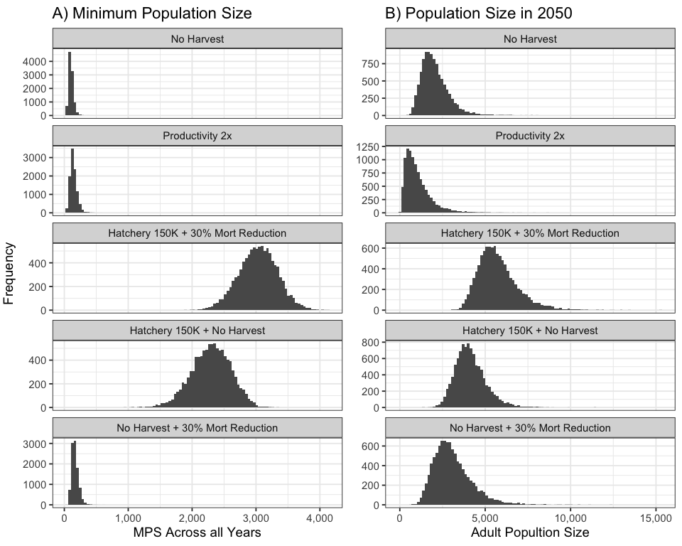

#### Alternative metrics

```r
adults.tab$MPS
```

| Scenario | Mean | SD | Lower1 | Upper99 | Lower95 | Upper95 |
| --- | --- | --- | --- | --- | --- | --- |
| No Harvest | 105.2340 | 35.61368 | 46.36358 | 214.3890 | 52.53906 | 189.5200 |
| Productivity 2x | 144.3803 | 54.56239 | 52.94299 | 316.8971 | 62.90880 | 273.5819 |
| Hatchery 150K + 30% Mort Reduction | 3032.1336 | 302.01663 | 2320.54415 | 3728.8173 | 2427.81981 | 3611.7761 |
| Hatchery 150K + No Harvest | 2294.0261 | 308.02683 | 1516.98294 | 2942.3768 | 1658.55238 | 2857.3897 |
| No Harvest + 30% Mort Reduction | 167.3322 | 53.46572 | 79.14151 | 333.1242 | 88.21456 | 292.1311 |

```r
adults.tab$POP2050
```

| Scenario | Mean | SD | Lower1 | Upper99 | Lower95 | Upper95 |
| --- | --- | --- | --- | --- | --- | --- |
| No Harvest | 2058.243 | 804.5733 | 805.4744 | 4680.302 | 922.0798 | 4000.023 |
| Productivity 2x | 1058.498 | 792.9588 | 123.7104 | 3905.453 | 174.5112 | 3179.466 |
| Hatchery 150K + 30% Mort Reduction | 5742.596 | 1171.6634 | 3773.6835 | 9391.999 | 3998.5491 | 8576.641 |
| Hatchery 150K + No Harvest | 4140.913 | 907.5066 | 2453.2990 | 6856.218 | 2674.7418 | 6248.435 |
| No Harvest + 30% Mort Reduction | 3105.621 | 1145.1856 | 1280.5496 | 6836.618 | 1457.7829 | 5861.226 |

Empirial cumulative distribution plots of performance metrics.

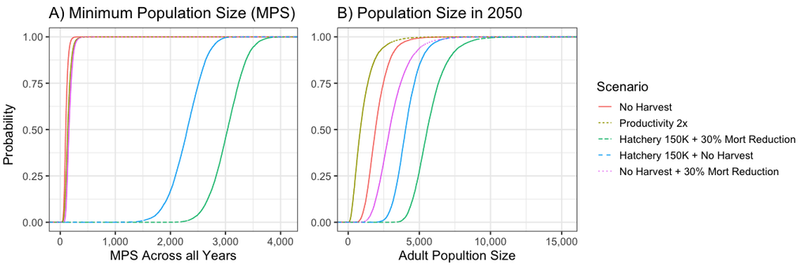

```r
p.ecdf <- PlotMetricECDF(run.set, type="both", panel.widths = c(1,1.75))
```

```r
# ggsave(filename = "hatchery-ecdf.png", width=10, height=4, plot=p.ecdf)
```

## Post Processing and Figures

```r
save(all.runs, file = "sim-runs.RData")
```

```r
saveWorkbook(wb, "results.xlsx", overwrite = TRUE)
saveWorkbook(wb.out, "outcomes.xlsx", overwrite = TRUE)
```

Summary of plotting objects available

```r
str(all.runs, max.level = 1)
```

```
List of 14
 $ Baseline                          :List of 5
 $ 10% mort reduction                :List of 5
 $ 30% mort reduction                :List of 5
 $ 50% mort reduction                :List of 5
 $ Hatchery 50K                      :List of 5
 $ Hatchery 100K                     :List of 5
 $ Hatchery 150K                     :List of 5
 $ Hatchery 250K                     :List of 5
 $ Hatchery 500K                     :List of 5
 $ No Harvest                        :List of 5
 $ Productivity 2x                   :List of 5
 $ Hatchery 150K + 30% Mort Reduction:List of 5
 $ Hatchery 150K + No Harvest        :List of 5
 $ No Harvest + 30% Mort Reduction   :List of 5
```

### Final RPA figure

Main RPA results figure only focused on average spawners as reliable endpoints were not available for the other potential metrics.

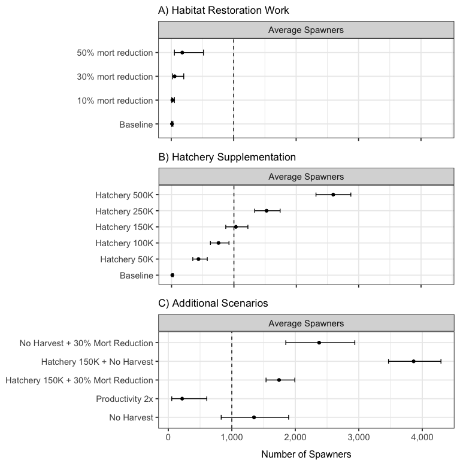

### Additinal Figures

These figures were reviewed in the workup prior to settling on the final RPA figure presented in the previous section.

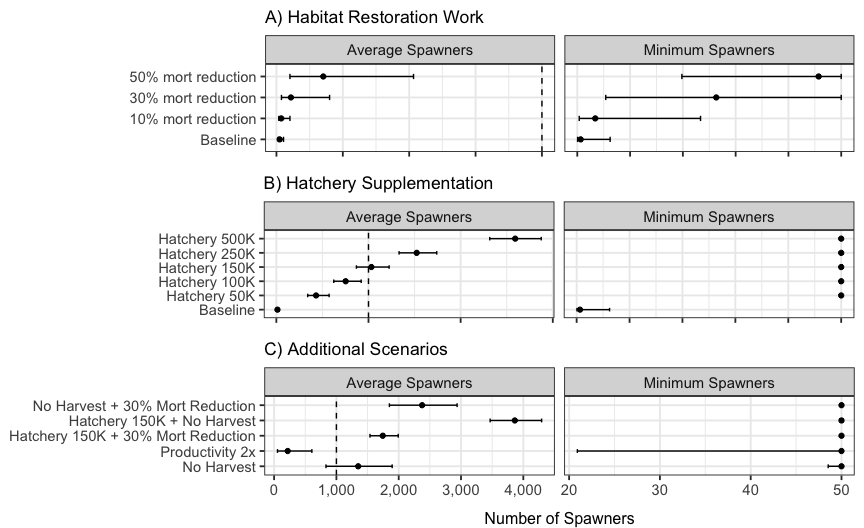

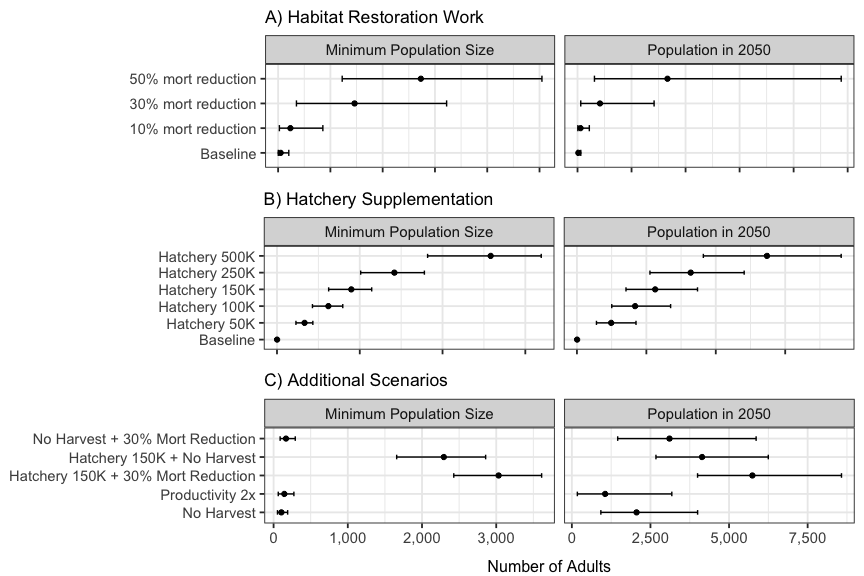